# 02_week slides

## Week 2 Tutorial: R Basics

### POP77001 Computer Programming for Social Scientists

##### Module website: tinyurl.com/POP77001

## R and development environments

- There is some choice of integrated development environments (IDEs) for R (StatET, ESS, R Commander)
- However, over the last decade RStudio became the de factor standard IDE for working in R
- You can also find R extensions for your favourite text editor (Atom, Sublime Text, Visual Studio Code, Vim)
- For the purposes of consistency with Python part of the module, we will continue using Jupyter with R

## Running R in Jupyter

- In order to be able to run R kernel in Jupyter, you need to install package `IRkernel`:
  - Open R (in the terminal) or RStudio:
  - Run `install.packages("IRkernel")` to install the package
  - Wait until the package is installed
  - Run `IRkernel::installspec()` to initialize R kernel for Jupyter
  - Now you should be able to launch or edit a notebook with R kernel

Tip: When starting working with R in Jupyter run `options(jupyter.rich_display = FALSE)` command to switch off pretty printing and get the output (albeit less neat) consistent with output in RStudio

## `IRkernel` installation and initialization

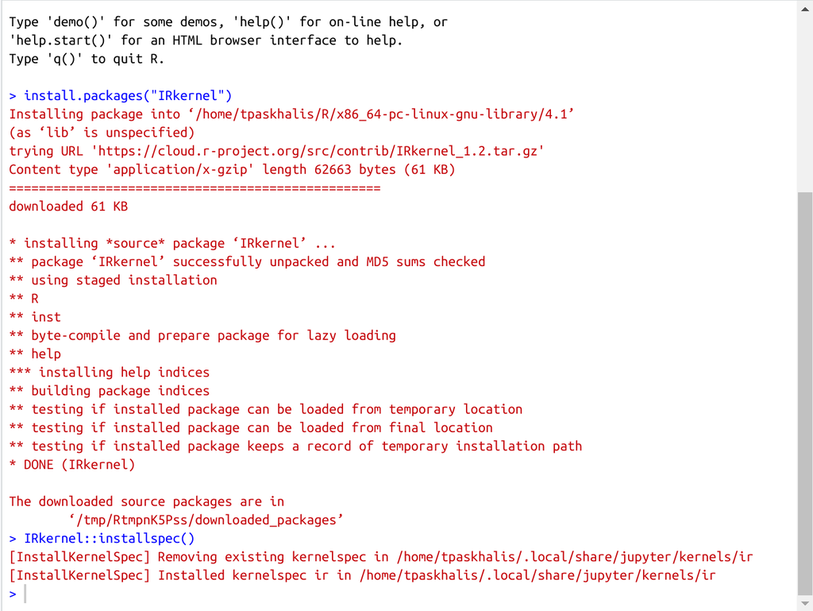

## Jupyter Notebook demonstration

[figure not shown]

## Jupyter Notebook demonstration continued

[figure not shown]

## R Script

- Usually you want to have a record of what analysis was done and how you did it.
- So, instead of writing all your R commands in the interactive console,
- You can create an R script, write them there and run then together or one at a time.
- R script is a file with `.R` extension and contains a collection of valid R commands.

## R Markdown

- Markdown:
  - Easy-to-read and easy-to-write plain text format;
  - Separates content from its appearance (rendition);
  - Widely used across industry sectors and academic fields;
  - `.md` file extension.
- RMarkdown:
  - Allows combining of R commands with regular text;
  - Compiles into PDF/DOC/HTML and other formats;
  - Can be converted into slide deck or even website!
  - `.Rmd` file extension

Extra: [Ch 27: R Markdown in Wickham & Grolemund 2017](https://r4ds.had.co.nz/r-markdown.html)

## Markdown formatting basics

- Use `_` or `*` for emphasis (single - italic, double - bold, triple - bold and italic)
  - `*one*` becomes *one*, `__two__` - **two** and `***three***` - *three*
- Headers or decreasing levels follow `#`, `##`, `###`, `####` and so on
- (Unordered) Lists follow marker `-`, `+` or `*`
  - Start at the left-most position for top-level
  - Indent four space and use another marker for nesting like here
- (Numbered) Lists use `1.` (counter is auto-incremented)
- Links have syntax of `[some text here](url_here)`
- Images similarly: `![alt text](url or path to image)`

## R Markdown example

````
Some text in *italic* and **bold**

Simple list:

- A
- B

Ordered list:

1. A
1. B

Example, where $Y = X + 5$

```{r}
x <- 3
y <- x + 5
y
```
````

## R Markdown example

Some text in *italic* and **bold**

Simple list:

- A
- B

Ordered list:

1. A
2. B

Example, where $Y = X + 5$

```
{r}
x <- 3
y <- x + 5
y
```

## Naming conventions

- Even while allowed in R, do not use `.` in variable names (it works as an object attribute in Python)
- Do not name give objects the names of existing functions and variables (e.g. `c`, `T`, `list`, `mean`)
- Use **UPPER_CASE_WITH_UNDERSCORE** for named constants (e.g. variables that remain fixed and unmodified)
- Use **lower_case_with_underscores** for function and variable names

Extra: [Style guide by Hadley Wickham](http://adv-r.had.co.nz/Style.html)

## Code layout

- Limit all lines to a maximum of 79 characters.
- Break up longer lines

```
my_long_vector <- c(
  1, 2, 3, 4, 5, 6, 7, 8, 9, 10, 11, 12, 13, 14, 15, 16, 17, 18, 19, 20, 21, 22,
  23, 24, 25, 26, 27, 28, 29, 30, 31, 32, 33, 34, 35, 36, 37, 38, 39, 40, 41,
  42, 43, 44, 45, 46, 47, 48, 49, 50, 51, 52, 53, 54, 55, 56, 57, 58, 59, 60
)

long_function_name <- function(a = "a long argument",
                               b = "another argument",
                               c = "another long argument") {
  # As usual code is indented by two spaces.
}
```

## Reserved words

There are 14 (plus some variations of them) reserved words in R that cannot be used as identifiers.

| `break` | `NA` |
| --- | --- |
| `else` | `NaN` |
| `FALSE` | `next` |
| `for` | `NULL` |
| `function` | `repeat` |
| `if` | `TRUE` |
| `Inf` | `while` |

Source: [R reserved words](https://stat.ethz.ch/R-manual/R-devel/library/base/html/Reserved.html)

## Exercise 1: Vector subsetting

- Load built-in R object `letters` (lower-case letters of the Roman alphabet)
- Calculate its length
- Generate a vector of integers that starts from 1 and has the same length as `letters`
- Assign to each integer corresponding lower-case letter as its name
- Use these names to subset all vowels
- Now, repeat the subsetting, but using indices rather than names

Tip: You can use function `which()` for determining the indices of vowels

```r
letters
```

```
 [1] "a" "b" "c" "d" "e" "f" "g" "h" "i" "j" "k" "l" "m" "n" "o" "p" "q" "r" "s"
[20] "t" "u" "v" "w" "x" "y" "z"
```

## Tabulation and crosstabulation in R

- R function `table()` provides an easy way of summarizing categorical variables
- Note that implicitly variables represented as character vectors are converted to factors

```r
# Top 10 most populous settlements on the island of Ireland
# https://en.wikipedia.org/wiki/List_of_settlements_on_the_island_of_Ireland_by_population
top_10_settlements <- c(
    "Dublin", "Belfast", "Cork", "Limerick", "Derry",
    "Galway", "Newtownabbey", "Bangor", "Waterford", "Lisburn"
)
```

```r
# Corresponding provinces
provinces <- c(
    "Leinster", "Ulster", "Munster", "Munster", "Ulster",
    "Connacht", "Ulster", "Ulster", "Munster", "Ulster"
)
```

```r
# Given that each town appears only once, cross-tabulation might not be the most informative
table(top_10_settlements, provinces)
```

```
                  provinces
top_10_settlements Connacht Leinster Munster Ulster
      Bangor              0        0       0      1
      Belfast             0        0       0      1
      Cork                0        0       1      0
      Derry               0        0       0      1
      Dublin              0        1       0      0
      Galway              1        0       0      0
      Limerick            0        0       1      0
      Lisburn             0        0       0      1
      Newtownabbey        0        0       0      1
      Waterford           0        0       1      0
```

```r
# Instead, we can just get tabulate the `provinces` vector
# and check the value counts for each province
table(provinces)
```

```
provinces
Connacht Leinster  Munster   Ulster
       1        1        3        5
```

## Exercise 2: Working with attributes and factors

- As you note the output of `table(provinces)` is sorted alphabetically
- Change this to reflect the actual counts
- First, let's store the result of tabulation for later re-use
- Start from exploring the structure of this object with `str()`
- What are the 2 main parts of this object? How are they stored?
- Extract the relevant parts from the stored object
- Save them as a named vector with provinces as names and counts as values
- Use `sort()` function to sort the vector in a decreasing order (from largest to smallest)
- Convert the original `provinces` vector into a factor with the levels ordered accordingly
- Re-run `table(provinces)`

```r
tab <- table(provinces)
```

## Week 2 Exercise (unassessed)

- Save a `letters` object under a different name
- Convert saved object into a matrix of 13 rows and 2 columns
- Subset letter 'f' using indices
- Concatenate 3 copies of `letters` object together in a single character vector
- Convert it into a 3-dimensional array, where each dimension appears as a matrix above
- Subset all letters 'f' across all 3 dimensions